# EDA Project 1

Tyler

2022-10-05

```r
library(tidyverse)
library(seriation)
library(tidyquant)
```

```r
airbnb <- read.csv("~/Airbnb_Open_data.csv")
```

```r
airbnb <- airbnb %>%
  select(id, host.id,neighbourhood.group,neighbourhood,room.type,Construction.year,price,
         service.fee,minimum.nights, number.of.reviews, review.rate.number, availability.365)
```

# **Chapter 1:** Data Descriptions

The following data is data taken from Airbnb in the New York City. This data is from the year 2019-2022. The variables in the data consist of ID, Name, host.id, host_identify_verified, host.name, neighbourhood.group, neighbourhood, lat, long, country, country.code, instant_bookable, cancellation_policy, room.type, construction.year, price, service.fee, minium.nights,number.of.reviews, last.review, reviews.per.month, review.rate.number, caculated.host.listings.count, availability.365, and house_rules. The price and service.fee are in USD.

# **Chapter 2:** EDA

## **Section 1:** I will be finding the center, spread, shape of the distribution for each variable. I also will be Checking for outliers

### **Price**

```r
airbnb %>%
  pull(price) %>%
  psych::describe()
```

|  | vars | n | mean | sd | median | trimmed | mad | min | max | range | skew | kurtosis | se |
| --- | --- | --- | --- | --- | --- | --- | --- | --- | --- | --- | --- | --- | --- |
| X1 | 1 | 102352 | 625.2935 | 331.6716 | 624 | 625.3293 | 425.5062 | 50 | 1200 | 1150 | 0.00133659 | -1.194226 | 1.036717 |

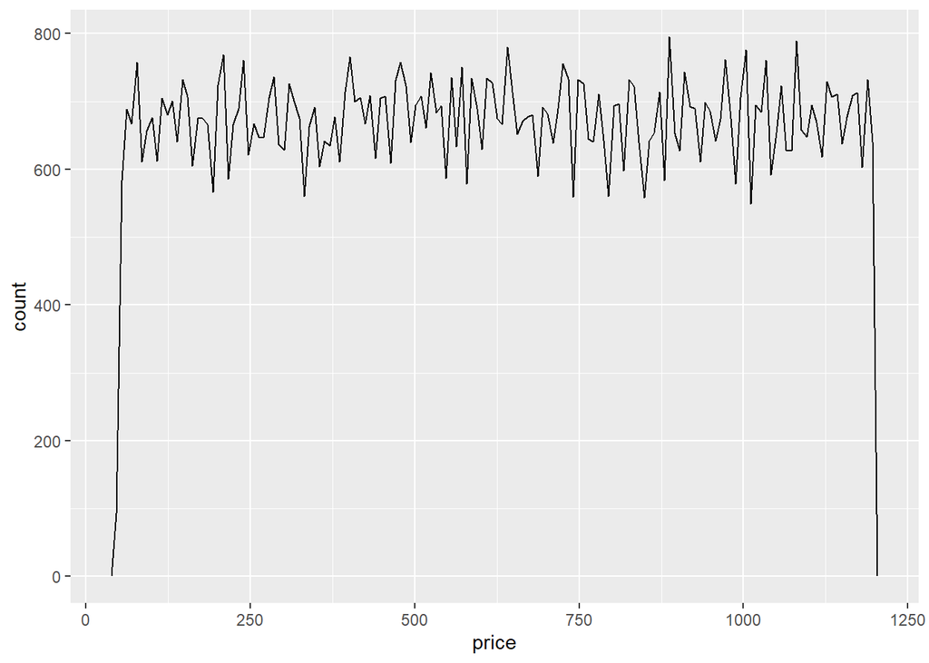

```r
airbnb %>% drop_na() %>%
  ggplot(mapping = aes(x = price)) +
  geom_freqpoly(bins = 150)
```

```r
airbnb %>%
  filter(price == 50)
```

| id | host.id | neighbourhood.group | neighbourhood | room.type | Construction.year | price | service.fee | minimum.nights | number.of.reviews | review.rate.number | availability.365 |
| --- | --- | --- | --- | --- | --- | --- | --- | --- | --- | --- | --- |
| 1200164 | 81492867264 | Manhattan | Washington Heights | Private room | 2021 | 50 | 10 | 2 | 136 | 4 | 312 |
| 1530992 | 17916840650 | Manhattan | Upper West Side | Entire home/apt | 2009 | 50 | 10 | 3 | 22 | 3 | 408 |
| 1917049 | 19719126508 | Queens | Astoria | Entire home/apt | 2006 | 50 | 10 | 3 | 17 | 1 | 76 |
| 2360546 | 3186487847 | Brooklyn | Bedford-Stuyvesant | Private room | 2011 | 50 | 10 | 3 | 13 | 1 | 68 |
| 2684194 | 37153412057 | Brooklyn | Williamsburg | Entire home/apt | 2006 | 50 | 10 | 2 | 11 | 1 | 62 |
| 3089030 | 65979986265 | Manhattan | Upper West Side | Entire home/apt | 2018 | 50 | 10 | 1 | 0 | 2 | 28 |
| 3582786 | 53342813841 | Brooklyn | Williamsburg | Private room | 2003 | 50 | 10 | 5 | 6 | 5 | 217 |
| 3823589 | 39739887079 | Brooklyn | Bedford-Stuyvesant | Private room | 2019 | 50 | 10 | 2 | 145 | 1 | 5 |
| 5693125 | 7170817633 | Brooklyn | Williamsburg | Private room | 2010 | 50 | 10 | 2 | 1 | 2 | 7 |
| 5923986 | 32495213494 | Brooklyn | Williamsburg | Private room | 2011 | 50 | 10 | 1 | 0 | 5 | 162 |

[output cut: 84 more lines]

I noticed that there was abnormal low value for price. To make sure it was not an outlier I wanted to check the room type. The room type listed for it is a private room which would make since for why it is only $50 a night. Some have them listed as an entire home/apartment. This could have something to do with the location of the Airbnb listed. This would require further investigation. Also the distribution is pretty symmetrical.